# R by Example: Analyzing RECS using data.table (Solution a)

James Henderson, CSCAR

February 05, 2020

## Step 1 - Header and libaries

Before beginning, state your goals and use a header to document our work.

1. Open the template script.
2. Update the title, description, author, and date information.
3. Use `library` to add `"tidyverse"` and `"data.table"` to the search path. Here is an example header.

```r
# R by Example: Analyzing RECS using data.table
# Solution to participant example (a)
#
# In this script, you will use the 2015 RECS data to examine
# how thermostat behavior impacts the difference between day and night
# temperatures in winter, while someone is home.
#
# Specifically, this sript estimates the national average temperatures, in homes
# that use space heating, during the day when someone is home and at night for
# homes grouped by thermostat behavior.
#
# Data Source:
# https://www.eia.gov/consumption/residential/data/2015/index.php?view=microdata
#
# Updated: February 5, 2020
# Author: James Henderson
# 80: --------------------------------------------------------------------------
```

Always load libraries at the top of your script.

```r
# libraries: -------------------------------------------------------------------
library(tidyverse); library(data.table)
```

## Step 2 - Read data

### Read data

First, read the data using a flag to decide whether to read from the url or a local file.

```r
# data: ------------------------------------------------------------------------
url = paste0(
  'https://www.eia.gov/consumption/residential/data/2015/csv/',
  'recs2015_public_v4.csv'
)
local_file = './recs2015_public_v4.csv'

# use local file if it exists, if not use url and save locally
if ( !file.exists(local_file) ) {
  recs = fread(url)
  fwrite(recs, file = local_file)
} else {
  recs = fread(local_file)
}
```

## Step 3 - Prepare Data

### Select and format variables

Next, format the data for analysis (as `recs_core`) by selecting key variables and giving them names that are easy for you to remember and type, while also being clear to another reader. My convention is to always use lower `snake_case`. Below are what the first few rows of the solution look like.

For this section you’ll want to recall `dt[i, j, by]`, where: a. `j` is a list (use `.()`) where you select or create column variables b. `by` is a list or character vector for grouped operations c. `i` is a logical vector used to select cases.

To add labels to variables selected in `j` use `factor()`.

Here are the core variables we’ll need:

- DOEID (`id`)
- NWEIGHT (`weight`)
- HEATHOME (`heat_home`)
- EQUIPMUSE (`therm`)
- TEMPHOME (`temp_home`)
- TEMPNITE (`temp_night`).

```r
# clean up key variables used in this problem: ---------------------------------
neg_to_na = function(x) {
  ifelse( x < 0, NA, x)
}

recs_core =
  recs[,
   .(
     # id variables
     id = DOEID,
     weight = NWEIGHT,
     # grouping factor
     therm = factor(EQUIPMUSE, levels = c(1:5, 9),
              labels = c(
                        'Set one temp',
                        'Manually adjust',
                        'Program thermostat',
                        'Turn equipment on/off',
                        'No control',
                        'Other'
                        )
              ),
     # case selection
     heat_home = factor(HEATHOME, 0:1, c('No', 'Yes') ),
     # temp variables
     temp_home = neg_to_na(TEMPHOME),
     temp_night = neg_to_na(TEMPNITE)
    ) ]
recs_core
```

```
##          id   weight                 therm heat_home temp_home temp_night
##    1: 10001 12085.16    Program thermostat       Yes        69         60
##    2: 10002 14410.20          Set one temp       Yes        75         72
##    3: 10003 23325.95          Set one temp       Yes        70         68
##    4: 10004 12165.33       Manually adjust       Yes        68         65
##    5: 10005 16717.67       Manually adjust       Yes        68         66
##   ---
## 5682: 15682 14190.77                 Other       Yes        72         75
## 5683: 15683 13617.69       Manually adjust       Yes        75         60
## 5684: 15684 20365.18          Set one temp       Yes        67         67
## 5685: 15685 15110.20          Set one temp       Yes        72         72
## 5686: 15686 31921.76 Turn equipment on/off       Yes        80         75
```

### Filter cases

Reduce `recs_core` to those cases/homes that use space heating in winter.

```r
# filter cases to those that use space heating in winter: ----------------------
recs_core = recs_core[heat_home == 'Yes']
```

### Replicate Weights

Finally, set aside the replicate weights for later use and pivot them to a longer format using `data.table::melt()`:

- DOEID (`id`)
- BRRWT1-BRRWT96

```r
# replicate weights, for computing standard errors: ----------------------------
## pivoted to a longer format to facilitate dplyr "vectorization"
weights_long =
  recs[, c('DOEID', grep('^BRRWT', names(recs), value = TRUE)),  with = FALSE
  ] %>%
  melt( data = ., id.vars = 'DOEID', patterns('^BRRWT'),
        variable.name = 'replicate', value.name = 'weight')

setnames(weights_long, c('id', 'replicate', 'weight'))

weights_long
```

```
##            id replicate    weight
##      1: 10001    BRRWT1 16555.311
##      2: 10002    BRRWT1 21486.287
##      3: 10003    BRRWT1 12297.437
##      4: 10004    BRRWT1 18553.959
##      5: 10005    BRRWT1  8075.744
##     ---
## 545852: 15682   BRRWT96 20183.445
## 545853: 15683   BRRWT96 19681.917
## 545854: 15684   BRRWT96 29148.112
## 545855: 15685   BRRWT96 20695.043
## 545856: 15686   BRRWT96 17836.113
```

In this analysis, the first step is to form point estimates of the average national “day with someone home” and “night” temperatures. Do that by forming weighted (NWEIGHT/`weight`) means of temperatures (TEMPHOME/`temp_home`, TEMNITE/`temp_night`) by group (EQUIPMUSE/`therm`).

To produce the plot at the end of this analysis, we’ll want the temperatures in a longer format – this is a good time to achieve that using `data.table::melt()`.

```r
# point estimates for winter temperatures by thermostat behavior: --------------

## pivot to a longer format and then form weighted sums by group
temps_by_type_therm =
  melt( recs_core,
        id.vars = c('id', 'therm', 'weight'),
        measure.vars = patterns('^temp_'),
        variable.name = 'type',
        value.name = 'temp'
  ) %>%
  .[ , .(avg_temp = sum(temp * weight) / sum(weight)) , .(type, therm)]
temps_by_type_therm
```

```
##           type                 therm avg_temp
##  1:  temp_home    Program thermostat 69.43345
##  2:  temp_home          Set one temp 70.27102
##  3:  temp_home       Manually adjust 70.05536
##  4:  temp_home Turn equipment on/off 69.96657
##  5:  temp_home            No control 69.71900
##  6:  temp_home                 Other 69.49875
##  7: temp_night    Program thermostat 66.37166
##  8: temp_night          Set one temp 69.52650
##  9: temp_night       Manually adjust 67.54028
## 10: temp_night Turn equipment on/off 67.29735
## 11: temp_night            No control 67.93104
## 12: temp_night                 Other 66.89337
```

### Step 5 - Replicate Estimates

Recall that this is survey data and not an identically distributed sample of US households. As such, to estimate standard errors we will use the replicate weights method in which we repeatedly recomptue the estimates from step 4, each time replacing NWEIGHT/`weight` with one of the 96 replicate weights. To do this efficiently:

The result should have rows giving the weighted average temperature for each unique combination of thermostat behavior, temperature type, and set of replicate weights.

```r
# replicate winter temperature estimates, for standard errors: -----------------

## 6 therm values, 2 types, 96 replicate weights = 1152 rows
temps_by_type_therm_repl =
  ### each row is a temperature type for a single home
  melt( recs_core,
        id.vars = c('id', 'therm'),
        measure.vars = patterns('^temp_'),
        variable.name = 'type',
        value.name = 'temp'
  ) %>%
  ### join with replicate weights, each previous row is now 96 rows
  merge(weights_long, ., by = c('id'), all = FALSE, allow.cartesian = TRUE) %>%
  .[, .(avg_temp_repl = sum(temp * weight) / sum(weight)),
      .(type, therm, replicate)]
temps_by_type_therm_repl
```

```
##             type              therm replicate avg_temp_repl
##    1:  temp_home Program thermostat    BRRWT1      69.48928
##    2: temp_night Program thermostat    BRRWT1      66.37956
##    3:  temp_home Program thermostat    BRRWT2      69.37778
##    4: temp_night Program thermostat    BRRWT2      66.32244
##    5:  temp_home Program thermostat    BRRWT3      69.46359
##   ---
## 1148: temp_night              Other   BRRWT94      68.03083
## 1149:  temp_home              Other   BRRWT95      69.30715
## 1150: temp_night              Other   BRRWT95      66.18868
## 1151:  temp_home              Other   BRRWT96      70.33578
## 1152: temp_night              Other   BRRWT96      68.23114
```

## Step 6 - Standard Errors and confidence bounds

Once we have the replicate estimates for our quantities of interest, we estimate the variance of the point estimates from step 4 using the sum of squared deviations of the replicate estimates around the original point estimates, scaling up by a factor determined in the process of formulating the replicate weights. The standard error is the square root of this variance estimate.

To accomplish this:

1. Join the point estimates from step 4 with the replicate estimates from step 5 using `merge()`.
2. Estimate the standard error for each point estimate, using the same grouping structure as used in step 4 to form the point estimates.
3. Add columns `lwr` and `upr` for, respectively, the lower and upper 95% confidence bounds using the point estimate +/- $\Phi^{-1}(.975)$ (or 1.96) times the standard error. This is best done using reference semantics `:=`.

```r
# compute standard errors and CIs: ---------------------------------------------
## 1. Join replicate and point estimates
## 2. Compute std error using scaled RMSE of replicates around point estimates
## 3. Form confidence intervals using standard methods

## Refer to the link below for std error computations, see page 3
## the standard error is the square root of the variance estimate
## https://www.eia.gov/consumption/residential/data/2015/pdf/microdata_v3.pdf

## compute standard errors and retain point estimate
avg_temp_by_type_therm =
 merge(
   temps_by_type_therm_repl,
   temps_by_type_therm,
   by = c('therm', 'type')
 ) %>%
 .[, .( avg_temp = avg_temp[1],
        se = 2 * sqrt( mean( {avg_temp_repl - avg_temp}^2 ) )
      ),
   .(type, therm)]

## add confidence bounds using reference semantics
avg_temp_by_type_therm[,
    `:=`( lwr = avg_temp - qnorm(.975) * se,
          upr = avg_temp + qnorm(.975) * se ) ]
```

## Step 7 - Plot the results

Create a plot of the results using ggplot2 and following the template from the example.

To get nice labels for temperature `type` use reference semantics (`:=`) to create a new factor variable `Winter Temperature`

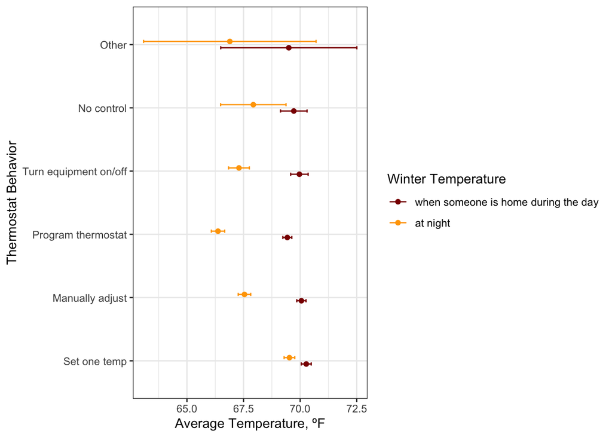

```r
# visualize the results: -------------------------------------------------------
## New factor for nice labels
avg_temp_by_type_therm[,
  `Winter Temperature` :=
            factor(type,
                   levels = c('temp_gone', 'temp_home', 'temp_night'),
                   labels = c('when no one is home during day',
                              'when someone is home during the day',
                              'at night'
                            )
            )
]

avg_temp_by_type_therm %>%
  ggplot( aes(y = avg_temp, x = therm, color = `Winter Temperature`) ) +
    geom_point( position = position_dodge(width = 0.2)) +
    geom_errorbar( aes(ymin = lwr, ymax = upr),
                   width = .1, position = position_dodge(width = 0.2)
    ) +
    theme_bw() +
    xlab('Thermostat Behavior') +
    ylab('Average Temperature, ºF') +
    scale_color_manual( values = c("darkred", "orange") ) +
    coord_flip()
```